# MSDS Assignment 1 Practical Machine Learning

## Data Visualization in R for Bodyfat data

Source: http://lib.stat.cmu.edu/datasets/bodyfat Assignment 1 Apoorv Saraogee Spring 2022 MSDS 499 Practical Machine Learning

```python
 #For ease of moving data from R to Python using rpy2
%load_ext rpy2.ipython
%R ata <- read.csv("~/Documents/assignment1bodyfat.csv")
%R utils::str(ata)
```

```
The rpy2.ipython extension is already loaded. To reload it, use:
  %reload_ext rpy2.ipython
'data.frame':	252 obs. of  15 variables:
 $ Density         : num  1.07 1.09 1.04 1.08 1.03 ...
 $ Body_Fat_Percent: num  12.3 6.1 25.3 10.4 28.7 20.9 19.2 12.4 4.1 11.7 ...
 $ Age             : int  23 22 22 26 24 24 26 25 25 23 ...
 $ Weight          : num  154 173 154 185 184 ...
 $ Height          : num  67.8 72.2 66.2 72.2 71.2 ...
 $ Neck            : num  36.2 38.5 34 37.4 34.4 39 36.4 37.8 38.1 42.1 ...
 $ Chest           : num  93.1 93.6 95.8 101.8 97.3 ...
 $ Abdomen         : num  85.2 83 87.9 86.4 100 94.4 90.7 88.5 82.5 88.6 ...
 $ Hip             : num  94.5 98.7 99.2 101.2 101.9 ...
 $ Thigh           : num  59 58.7 59.6 60.1 63.2 66 58.4 60 62.9 63.1 ...
 $ Knee            : num  37.3 37.3 38.9 37.3 42.2 42 38.3 39.4 38.3 41.7 ...
 $ Ankle           : num  21.9 23.4 24 22.8 24 25.6 22.9 23.2 23.8 25 ...
 $ Biceps          : num  32 30.5 28.8 32.4 32.2 35.7 31.9 30.5 35.9 35.6 ...
 $ Forearm         : num  27.4 28.9 25.2 29.4 27.7 30.6 27.8 29 31.1 30 ...
 $ Wrist           : num  17.1 18.2 16.6 18.2 17.7 18.8 17.7 18.8 18.2 19.2 ...
```

```python
%R library(Hmisc)
%R library(reshape)
%R library(ggplot2)
%R library(dplyr)
%R library(corrplot)
```

```
R[write to console]: Loading required package: lattice

R[write to console]: Loading required package: survival

R[write to console]: Loading required package: Formula

R[write to console]: Loading required package: ggplot2

R[write to console]:


R[write to console]:


R[write to console]: corrplot 0.92 loaded
```

StrVector with 16 elements.

| 'corrplot' | 'dplyr' | 'reshape' | ... | 'datasets' | 'methods' | 'base' |
| --- | --- | --- | --- | --- | --- | --- |

```python
%R atabody=ata[,c(2,1,3:15)] #putting focus of study as first column
```

|  | Body_Fat_Percent | Density | Age | Weight | Height | Neck | Chest | Abdomen | Hip | Thigh | Knee | Ankle | Biceps | Forearm | Wrist |
| --- | --- | --- | --- | --- | --- | --- | --- | --- | --- | --- | --- | --- | --- | --- | --- |
| 1 | 12.3 | 1.0708 | 23 | 154.25 | 67.75 | 36.2 | 93.1 | 85.2 | 94.5 | 59.0 | 37.3 | 21.9 | 32.0 | 27.4 | 17.1 |
| 2 | 6.1 | 1.0853 | 22 | 173.25 | 72.25 | 38.5 | 93.6 | 83.0 | 98.7 | 58.7 | 37.3 | 23.4 | 30.5 | 28.9 | 18.2 |
| 3 | 25.3 | 1.0414 | 22 | 154.00 | 66.25 | 34.0 | 95.8 | 87.9 | 99.2 | 59.6 | 38.9 | 24.0 | 28.8 | 25.2 | 16.6 |
| 4 | 10.4 | 1.0751 | 26 | 184.75 | 72.25 | 37.4 | 101.8 | 86.4 | 101.2 | 60.1 | 37.3 | 22.8 | 32.4 | 29.4 | 18.2 |
| 5 | 28.7 | 1.0340 | 24 | 184.25 | 71.25 | 34.4 | 97.3 | 100.0 | 101.9 | 63.2 | 42.2 | 24.0 | 32.2 | 27.7 | 17.7 |
| ... | ... | ... | ... | ... | ... | ... | ... | ... | ... | ... | ... | ... | ... | ... | ... |
| 248 | 11.0 | 1.0736 | 70 | 134.25 | 67.00 | 34.9 | 89.2 | 83.6 | 88.8 | 49.6 | 34.8 | 21.5 | 25.6 | 25.7 | 18.5 |
| 249 | 33.6 | 1.0236 | 72 | 201.00 | 69.75 | 40.9 | 108.5 | 105.0 | 104.5 | 59.6 | 40.8 | 23.2 | 35.2 | 28.6 | 20.1 |
| 250 | 29.3 | 1.0328 | 72 | 186.75 | 66.00 | 38.9 | 111.1 | 111.5 | 101.7 | 60.3 | 37.3 | 21.5 | 31.3 | 27.2 | 18.0 |
| 251 | 26.0 | 1.0399 | 72 | 190.75 | 70.50 | 38.9 | 108.3 | 101.3 | 97.8 | 56.0 | 41.6 | 22.7 | 30.5 | 29.4 | 19.8 |
| 252 | 31.9 | 1.0271 | 74 | 207.50 | 70.00 | 40.8 | 112.4 | 108.5 | 107.1 | 59.3 | 42.2 | 24.6 | 33.7 | 30.0 | 20.9 |

252 rows × 15 columns

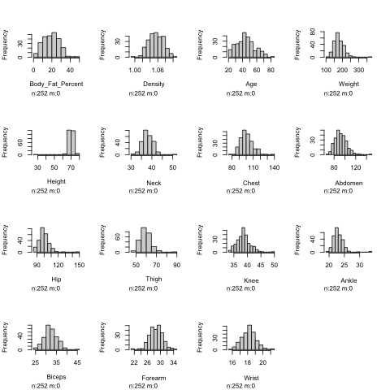

```
array([1.])
```

```python
%R hist.data.frame(atabody)
```

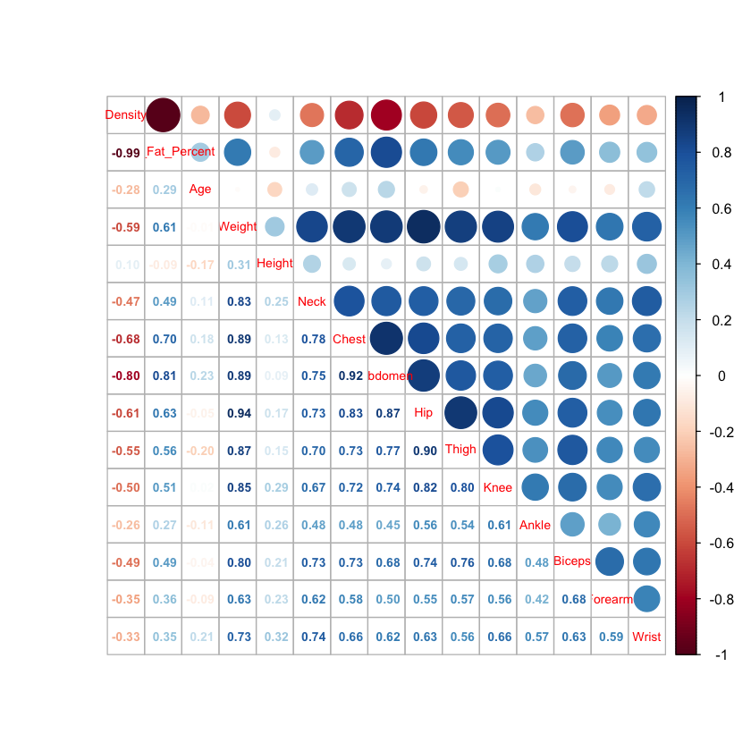

```python
ata <- read.csv("~/Documents/assignment1bodyfat.csv")
library(corrplot)
atacor=cor(ata)
corrplot.mixed(atacor, number.cex = 0.7, tl.cex = 0.7)
```

### Density is inversely related to Body_Fat_Percentage and is known, so will be taken out as a predictor or explanatory variable in future iterations. Abdomen, Chest, Hip and Weight all had correlation values above 0.6 with Body_Fat_Percentage (positive or negative).

```
Using  as id variables
```

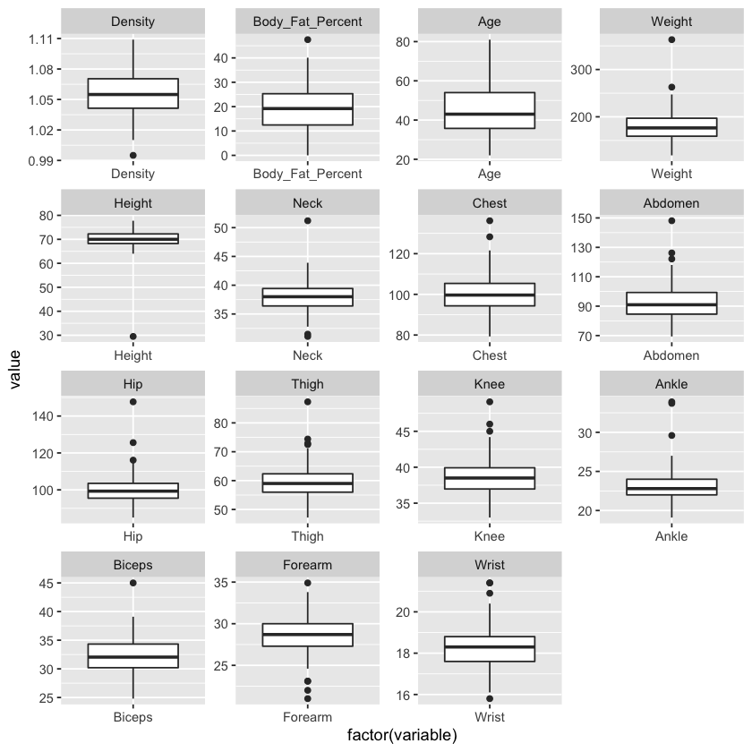

```python
ata <- read.csv("~/Documents/assignment1bodyfat.csv")
install.packages('reshape')
library(reshape)
library(ggplot2)
meltata<-melt(ata)
box <- ggplot(meltata, aes(factor(variable), value))
box + geom_boxplot() + facet_wrap(~variable, scale="free")
```

### R code did not run in rpy2 environment, so I used jupyters kernel to create boxplots:

### We see many outliers in knee, forearm, abdomen, thigh and hip, but less than 2% of the total dataset for each variable.

# Traditional Model

```python
#10fold cross validation
crossvalidation = KFold(n_splits=10, random_state=1, shuffle=True)
```

```python
#Traditional model
model = LinearRegression().fit(Xt, yt)
scoresr2 = cross_validate(model, Xt, yt, scoring="r2", cv=crossvalidation, n_jobs=1, return_train_score=True)
print("Training "+"Folds: " + str(len(scoresr2['train_score'])) + ", R2: " + str(np.mean(np.abs(scoresr2['train_score']))) + ", STD: " + str(np.std(scoresr2['train_score'])))
print("Test "+"Folds: " + str(len(scoresr2['test_score'])) + ", R2: " + str(np.mean(np.abs(scoresr2['test_score']))) + ", STD: " + str(np.std(scoresr2['test_score'])))
```

```
Training Folds: 10, R2: 0.7502787814054092, STD: 0.00994054507242574
Test Folds: 10, R2: 0.6737336935281805, STD: 0.0989908325387686
```

```python
scoresr2
```

```
{'fit_time': array([0.00128198, 0.00075483, 0.00062776, 0.00061202, 0.00060701,
        0.00061083, 0.00059175, 0.00058889, 0.00059009, 0.00063992]),
 'score_time': array([0.00042605, 0.00034618, 0.00034308, 0.00033808, 0.00033927,
        0.00033021, 0.00032711, 0.00033092, 0.00032902, 0.00033212]),
 'test_score': array([0.71058529, 0.71934047, 0.84036118, 0.58856074, 0.5721279 ,
        0.60903779, 0.52162054, 0.77476051, 0.77206301, 0.62887951]),
 'train_score': array([0.75049933, 0.74474733, 0.7320207 , 0.7597652 , 0.76087616,
        0.75517139, 0.75985094, 0.7398138 , 0.74010603, 0.75993694])}
```

```python
import pandas
import sklearn
import pwlf
import numpy as np
import matplotlib.pyplot as plt
from tabulate import tabulate

#cross-validation for traditional model
from sklearn.model_selection import train_test_split
from sklearn.linear_model import LinearRegression
from sklearn.model_selection import cross_val_score
from sklearn.model_selection import cross_validate
from sklearn.model_selection import KFold

#moves data from R to Python
atabody = %R atabody
```

```python
#Output variable
y=atabody.Body_Fat_Percent

#Multiple input variables or features
X=atabody.drop(columns='Body_Fat_Percent')
X=X.drop(columns='Density') #dropped due to inverse relationship
Xt=X.to_numpy() #explanatory variables
yt=y.to_numpy() #bodyfat or output variable
```

# Testing linearity assumption of model

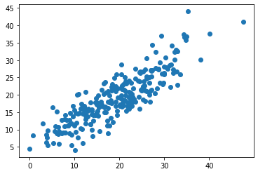

```python
#Traditional model used to obtain predictions for body fat percentage as ybar
ybar=model.predict(Xt)
import matplotlib.pyplot as plt
plt.scatter(yt,ybar)
```

The graph looks like a straight line supporting the linearity assumption in our model.

# Regularized model

```python
#Regularized regression with ridge regression
modelreg=sklearn.linear_model.RidgeCV(cv=10).fit(Xt,yt)
scoresregr2 = cross_validate(modelreg, Xt, yt, scoring="r2", cv=crossvalidation, n_jobs=1, return_train_score=True)
print("Training "+"Folds: " + str(len(scoresregr2['train_score'])) + ", R2: " + str(np.mean(np.abs(scoresregr2['train_score']))) + ", STD: " + str(np.std(scoresregr2['train_score'])))
print("Test "+"Folds: " + str(len(scoresregr2['test_score'])) + ", R2: " + str(np.mean(np.abs(scoresregr2['test_score']))) + ", STD: " + str(np.std(scoresregr2['test_score'])))
```

```
Training Folds: 10, R2: 0.7501420269756575, STD: 0.009908967150267253
Test Folds: 10, R2: 0.6736566425450766, STD: 0.09711209607170027
```

The regularized model performs worse than the traditional model, but very slightly and within the margin of error.

# Subset models

## Polynomial

```python
from sklearn.preprocessing import PolynomialFeatures
poly_reg = PolynomialFeatures(degree=2)
X_poly = poly_reg.fit_transform(Xt)
```

```python
X_poly.shape
```

```
(252, 105)
```

```python
Xt.shape
```

```
(252, 13)
```

```python
modelpoly = LinearRegression().fit(X_poly, yt)
ybar=modelpoly.predict(X_poly)

scorespolyr2 = cross_validate(modelpoly, Xt, yt, scoring="r2", cv=crossvalidation, n_jobs=1, return_train_score=True)
print("Training "+"Folds: " + str(len(scorespolyr2['train_score'])) + ", R2: " + str(np.mean(np.abs(scorespolyr2['train_score']))) + ", STD: " + str(np.std(scorespolyr2['train_score'])))
print("Test "+"Folds: " + str(len(scorespolyr2['test_score'])) + ", R2: " + str(np.mean(np.abs(scorespolyr2['test_score']))) + ", STD: " + str(np.std(scorespolyr2['test_score'])))
```

```
Training Folds: 10, R2: 0.7502787814054092, STD: 0.00994054507242574
Test Folds: 10, R2: 0.6737336935281805, STD: 0.0989908325387686
```

## Indicator

```python
Xtind=X
Xtind['Chest ind']=Xtind['Chest']
Xtind['Abdomen ind']=Xtind['Abdomen']
Xtind=Xtind.drop(columns='Chest')
Xtind=Xtind.drop(columns='Abdomen')
Xtindnp=Xtind.to_numpy()
Xtindnp[:,-1]=np.transpose(np.digitize(Xtindnp[:,-1], bins=[84.6,91,99.3])) #25th, 50th, 75th percentile for Abdomen
Xtindnp[:,-2]=np.transpose(np.digitize(Xtindnp[:,-2], bins=[94.4,100,105.4])) #25th, 50th, 75th percentile for Chest
```

```python
modelind = LinearRegression().fit(Xtindnp, yt)
scoresindr2 = cross_validate(modelind, Xtindnp, yt, scoring="r2", cv=crossvalidation, n_jobs=1, return_train_score=True)
print("Training "+"Folds: " + str(len(scoresindr2['train_score'])) + ", R2: " + str(np.mean(np.abs(scoresindr2['train_score']))) + ", STD: " + str(np.std(scoresindr2['train_score'])))
print("Test "+"Folds: " + str(len(scoresindr2['test_score'])) + ", R2: " + str(np.mean(np.abs(scoresindr2['test_score']))) + ", STD: " + str(np.std(scoresindr2['test_score'])))
```

```
Training Folds: 10, R2: 0.7103444757325712, STD: 0.007876148532878696
Test Folds: 10, R2: 0.6062376362319204, STD: 0.1072023055129212
```

## Dichotomous

```python
Xtdi=X
Xtdi['Chest ind']=Xtdi['Chest']
Xtdi['Abdomen ind']=Xtdi['Abdomen']
Xtdi=Xtdi.drop(columns='Chest')
Xtdi=Xtdi.drop(columns='Abdomen')
Xtdinp=Xtdi.to_numpy()
Xtdinp[:,-1]=np.transpose(np.digitize(Xtdinp[:,-1], bins=[91])) #50th percentile bin for Abdomen
Xtdinp[:,-2]=np.transpose(np.digitize(Xtdinp[:,-2], bins=[100])) #50th percentile bin for Chest
```

```python
modeldi = LinearRegression().fit(Xtdinp, yt)
scoresdir2 = cross_validate(modeldi, Xtdinp, yt, scoring="r2", cv=crossvalidation, n_jobs=1, return_train_score=True)
print("Training "+"Folds: " + str(len(scoresdir2['train_score'])) + ", R2: " + str(np.mean(np.abs(scoresdir2['train_score']))) + ", STD: " + str(np.std(scoresdir2['train_score'])))
print("Test "+"Folds: " + str(len(scoresdir2['test_score'])) + ", R2: " + str(np.mean(np.abs(scoresdir2['test_score']))) + ", STD: " + str(np.std(scoresdir2['test_score'])))
```

```
Training Folds: 10, R2: 0.6557727922298028, STD: 0.01039557227108277
Test Folds: 10, R2: 0.5230381894680156, STD: 0.13878614223415653
```

## Piecewise

```python
atabody1=atabody[atabody['Chest']>100] #50th percentile
atabody2=atabody[atabody['Chest']<=100]
Xtpi1=atabody1.drop(columns='Body_Fat_Percent')
Xtpi1=Xtpi1.drop(columns='Density') #dropped due to inverse relationship
Xtpi2=atabody2.drop(columns='Body_Fat_Percent')
Xtpi2=Xtpi2.drop(columns='Density') #dropped due to inverse relationship
yt1=atabody1.Body_Fat_Percent
yt2=atabody2.Body_Fat_Percent

#Multiple input variables or features

modelpi1 = LinearRegression().fit(Xtpi1, yt1)
modelpi2 = LinearRegression().fit(Xtpi2, yt2)
```

```python
scorespi1 = cross_validate(modelpi1, Xtpi1, yt1, scoring="r2", cv=crossvalidation, n_jobs=1, return_train_score=True)
print("Training "+"Folds: " + str(len(scorespi1['train_score'])) + ", R2: " + str(np.mean(np.abs(scorespi1['train_score']))) + ", STD: " + str(np.std(scorespi1['train_score'])))
print("Test "+"Folds: " + str(len(scorespi1['test_score'])) + ", R2: " + str(np.mean(np.abs(scorespi1['test_score']))) + ", STD: " + str(np.std(scorespi1['test_score'])))
```

```
Training Folds: 10, R2: 0.7078519278638502, STD: 0.013330495475893024
Test Folds: 10, R2: 0.5481190566094207, STD: 0.285430712028238
```

```python
scorespi2 = cross_validate(modelpi2, Xtpi2, yt2, scoring="r2", cv=crossvalidation, n_jobs=1, return_train_score=True)
print("Training "+"Folds: " + str(len(scorespi2['train_score'])) + ", R2: " + str(np.mean(np.abs(scorespi2['train_score']))) + ", STD: " + str(np.std(scorespi2['train_score'])))
print("Test "+"Folds: " + str(len(scorespi2['test_score'])) + ", R2: " + str(np.mean(np.abs(scorespi2['test_score']))) + ", STD: " + str(np.std(scorespi2['test_score'])))
```

```
Training Folds: 10, R2: 0.6303951512263218, STD: 0.0153033509215643
Test Folds: 10, R2: 0.4022720460819139, STD: 0.22351138177397817
```

# Feature Engineering

```python
from sklearn.decomposition import PCA
pca = PCA(n_components=6)
principalComponents = pca.fit_transform(Xt)
```

```python
modelpca = LinearRegression().fit(principalComponents, yt)
scorespca = cross_validate(modelpca, principalComponents, yt, scoring="r2", cv=crossvalidation, n_jobs=1, return_train_score=True)
print("Training "+"Folds: " + str(len(scorespca['train_score'])) + ", R2: " + str(np.mean(np.abs(scorespca['train_score']))) + ", STD: " + str(np.std(scorespca['train_score'])))
print("Test "+"Folds: " + str(len(scorespca['test_score'])) + ", R2: " + str(np.mean(np.abs(scorespca['test_score']))) + ", STD: " + str(np.std(scorespca['test_score'])))
```

```
Training Folds: 10, R2: 0.7199901021915307, STD: 0.010487611694740072
Test Folds: 10, R2: 0.6541663793227996, STD: 0.10232894574881668
```

# Comparing models

```python
data = [["All variables", np.mean(np.abs(scoresr2['train_score'])),np.mean(np.abs(scoresr2['test_score'])) ],
        ["Regularized all variables", np.mean(np.abs(scoresregr2['train_score'])),np.mean(np.abs(scoresregr2['test_score']))],
        ["Indicator variables",np.mean(np.abs(scoresindr2['train_score'])),np.mean(np.abs(scoresindr2['test_score']))],
        ["Dichotomous variables", np.mean(np.abs(scoresdir2['train_score'])),np.mean(np.abs(scoresdir2['test_score']))],
       ["Polynomial variables", np.mean(np.abs(scorespolyr2['train_score'])),np.mean(np.abs(scorespolyr2['test_score']))],
       ["Piecewise variables",np.average([np.mean(np.abs(scorespi1['train_score'])), np.mean(np.abs(scorespi2['train_score']))]),np.average([np.mean(np.abs(scorespi1['test_score'])), np.mean(np.abs(scorespi2['test_score']))])],
       ["Principal Components", np.mean(np.abs(scorespca['train_score'])),np.mean(np.abs(scorespca['test_score']))]]
columns= [['model','train r2','test r2']]
print(tabulate(data, headers=["model","train r2", "test r2"]))
```

[output not shown]

```python
model=lm(Body_Fat_Percent ~ Age + Weight + Height + Neck + Chest + Abdomen + Hip + Thigh + Knee + Ankle + Biceps + Forearm + Wrist, data = ata)
```

```python
install.packages('olsrr')
library(olsrr)
all <- ols_step_all_possible(model)
```

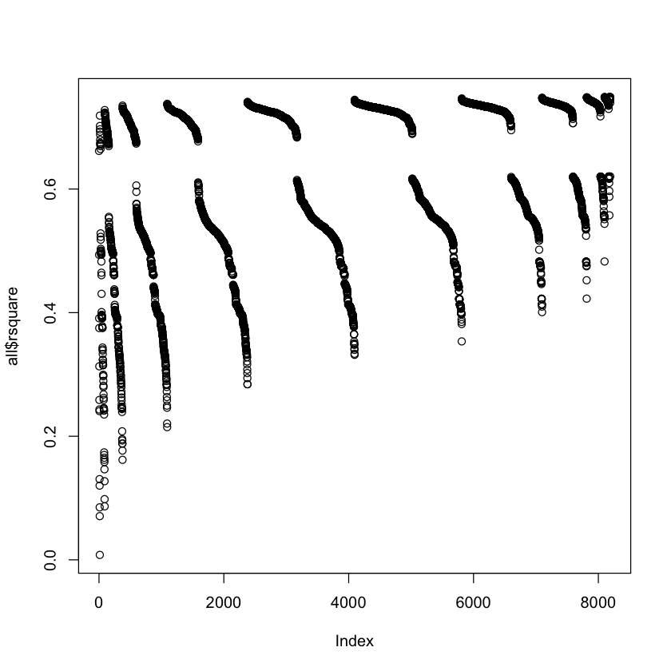

```python
plot(all$rsquare)
```

### The highest Rsquare value here corresponded to inded 8191 which includes all 13 explanatory variables (upper right corner).

# Chosen Model: All variables

## The model chosen will be linear regression using all 13 explanatory variables (the most complex model). Other models seem to lose information at being able to predict the bodyfat percentage.